# Life expectancy

Maria Fernanda Peniche and Franck Sombo

2024-12-10

# Introduction

Life expectancy is a critical metric of global health and well-being, reflecting the impact of healthcare access, economic development, and public policies. Variations in life expectancy across countries highlight disparities in socio-economic conditions and public health infrastructure. This report examines the relationship between life expectancy and key indicators such as health expenditure, vaccination coverage, GDP, and infant mortality. Through a series of visualizations, we aim to provide insights into how these factors interrelate and their implications for improving life expectancy.

# Global overview

Between 2000 and 2015, global life expectancy showed a consistent upward trend, increasing from approximately 67 years to 71.5 years. This growth reflects improvements in healthcare, public health initiatives, and living standards worldwide. By 2015, these cumulative efforts seem to have contributed to a notable increase in life expectancy.

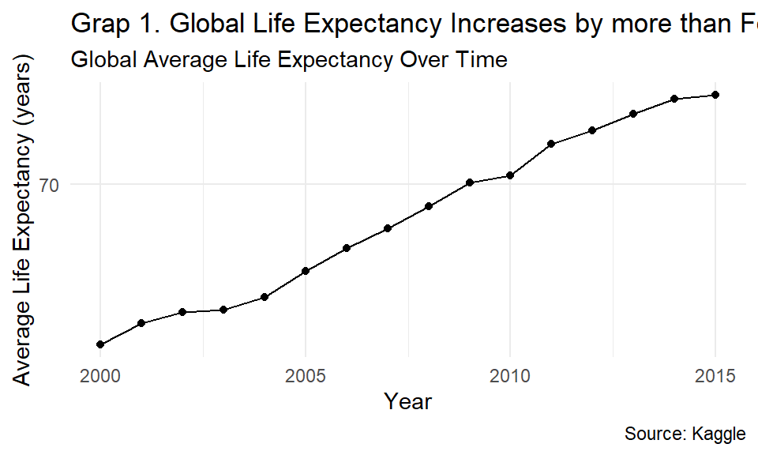

In the following table, we can observe the descriptive statistics of the global variables: Life Expectancy, GDP and Population.

Summary Statistics of Key Variables

| Variable | Mean | Median | StD |
| --- | --- | --- | --- |
| Life Expectancy | 69.35 | 72.20 | 9.53 |
| GDP | 7,664.40 | 1,841.09 | 14,466.24 |
| Population | 12,834,572.12 | 1,391,756.50 | 61,960,940.70 |

We can observe Life Expectancy by Country in the following map for the year 2015

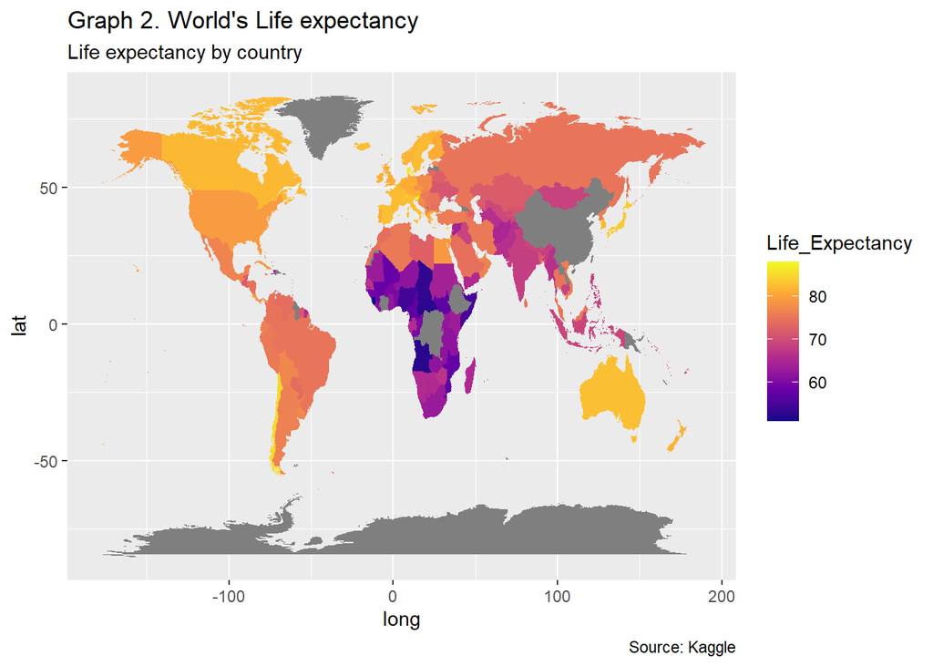

# Demographic Data

Demographic data, such as population size, country development, and urbanization levels, influence health outcomes and healthcare needs. Population trends also impact resource allocation and policy decisions, making demographic analysis essential for understanding variations in life expectancy across countries.

The following two graphs show the top 10 countries with the highest and lowest life expectancy per country in year 2015, which is the most recent year from the dataset.

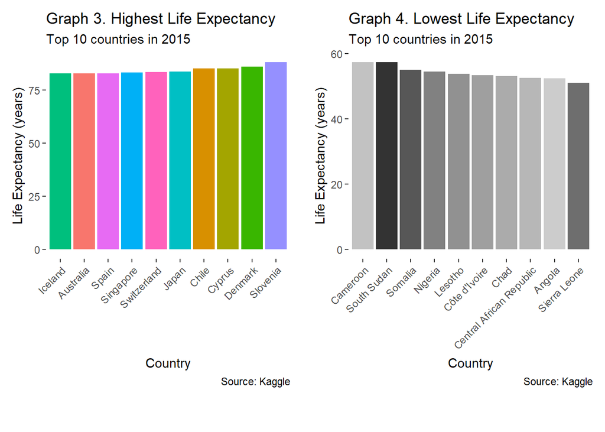

# Economic Factors

Economic factors, including GDP and health expenditure, play a significant role in shaping health outcomes. Countries with higher economic resources often allocate more funding to healthcare, leading to better infrastructure, access to services, and improved life expectancy. Examining these factors helps to uncover the economic drivers behind global health disparities. As such, the equitable distribution of wealth in a country tends to positively correlate with higher life expectancy.

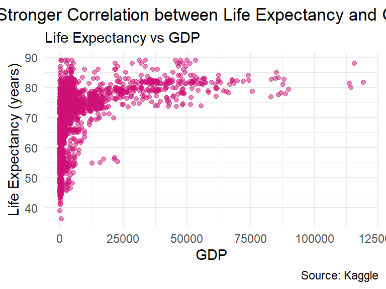

The more a country is developed, the higher their median life expectancy compared to developing countries. The gap between developed and developing countries in terms of median life expectancy is about 10 years, which is significant. Likewise, there are more developing countries with a life expectancy beneath the median line, than those with developed status (see Graph 7).

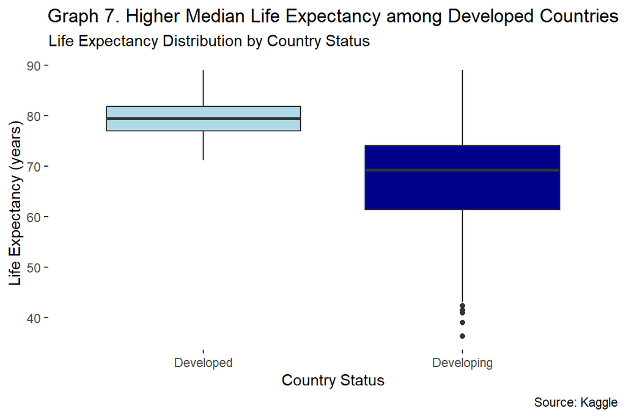

# Health Indicators

Health indicators are critical metrics used to evaluate the effectiveness of healthcare systems and public health policies. Metrics such as vaccination coverage, infant mortality rates, and disease prevalence provide insights into a population’s overall health and access to essential healthcare services. These indicators highlight disparities in healthcare outcomes across countries and their correlation with life expectancy.

We chose to analyze the average vaccination rates for the most recent year we have which is 2015.

[figure not shown]

Among countries with low life expectancy, African countries seem to have experienced more infant deaths in 2015. Relatively, the higher the population size, the higher number of infant deaths recorded. Issues related to health infrastructure, equitable access, socio-economic and environmental factors might constitute some challenges worth examining.

# France and the World

Examining France’s life expectancy trends in relation to global extremes—countries with the highest and lowest life expectancy mean over the years—offers valuable context for understanding global health disparities and the factors contributing to France’s life expectancy.

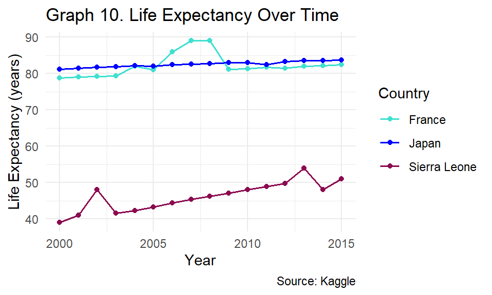